# Visualization_HW_1

Dmitrii Belousov

2024-09-21

# Importing data

```r
hogwarts <- read_csv("./dayavis_BI_2024/data/hogwarts_2024.csv")
hogwarts %>% psych::describe()
```

```
##                                    vars   n   mean     sd median trimmed    mad
## id                                    1 560 280.50 161.80  280.5  280.50 207.56
## house                                 2 560   2.47   1.08    2.0    2.46   1.48
## course                                3 560   3.95   2.04    4.0    3.94   2.97
## sex                                   4 560   1.41   0.49    1.0    1.38   0.00
## wandCore                              5 560   1.98   0.82    2.0    1.97   1.48
## bloodStatus                           6 560   1.50   0.80    1.0    1.37   0.00
## result                                7 560  59.71  96.12   70.5   67.44  88.21
## Defence against the dark arts exam    8 560  48.00  15.73   49.0   48.46  13.34
## Flying exam                           9 560  47.37  16.04   48.0   47.90  17.79
## Astronomy exam                       10 560  47.99  16.38   49.0   48.74  16.31
## Herbology exam                       11 560  47.75  16.21   49.0   48.45  14.83
## Divinations exam                     12 560  48.44  16.06   49.0   48.80  14.83
## Charms exam                          13 560  48.36  16.61   49.0   48.73  14.83
## History of magic exam                14 560  47.28  15.85   48.0   47.94  14.83
## Arithmancy exam                      15 560  48.38  15.92   50.0   48.90  16.31
## Care of magical creatures exam       16 560  48.11  16.32   49.0   48.67  16.31
## Muggle studies exam                  17 560  48.64  16.59   50.0   49.27  16.31
## Study of ancient runes exam          18 560  47.44  15.94   48.0   48.04  14.83
## Transfiguration exam                 19 560  48.24  21.49   49.0   48.14  21.50
## Potions exam                         20 560  46.62  27.89   47.0   46.09  34.10
## week_1                               21 560   1.33   8.28    1.0    1.06   5.93
## week_2                               22 560   1.16   8.38    1.0    1.21   5.93
## week_3                               23 560   1.41   8.51    1.0    1.47   5.93
## week_4                               24 560   1.82   8.31    1.0    1.81   5.93
## week_5                               25 560   0.92   8.98    1.0    1.13   5.93
## week_6                               26 560   1.45   8.48    1.0    1.45   5.93
## week_7                               27 560   1.53   7.98    1.0    1.58   5.93
## week_8                               28 560   1.60   8.35    1.0    1.62   5.93
## week_9                               29 560   1.63   8.99    1.0    1.70   5.93
## week_10                              30 560   1.46   8.64    1.0    1.53   5.93
## week_11                              31 560   1.59   8.75    1.0    1.65   5.93
## week_12                              32 560   1.69   8.61    1.0    1.93   5.93
## week_13                              33 560   0.74   9.30    0.0    0.77   7.41
## week_14                              34 560   1.53   8.47    1.0    1.60   5.93
## week_15                              35 560   1.74   8.37    1.0    1.79   5.93
## week_16                              36 560   1.64   8.80    1.0    1.78   5.93
## week_17                              37 560   1.80   8.76    1.0    1.69   5.93
## week_18                              38 560   1.71   8.33    1.0    1.90   5.93
## week_19                              39 560   0.81   8.55    0.0    0.90   7.41
```

[output cut: 67 more lines]

```
## week_26                             -20  20    40  0.02     1.15 0.35
## week_27                             -50  20    70 -0.38     2.57 0.38
## week_28                             -20  20    40  0.08     0.79 0.36
## week_29                             -20  20    40  0.00     1.38 0.34
## week_30                             -20  20    40 -0.01     0.86 0.37
## week_31                             -20  20    40 -0.11     0.94 0.37
## week_32                             -20  20    40  0.11     1.06 0.36
## week_33                             -20  20    40 -0.03     1.46 0.34
## week_34                             -20  20    40 -0.18     0.81 0.38
## week_35                             -20  20    40 -0.14     1.01 0.37
## week_36                             -20  20    40  0.02     0.91 0.37
## week_37                             -20  20    40 -0.18     1.27 0.35
## week_38                             -20  20    40 -0.06     1.11 0.36
## week_39                             -20  20    40 -0.09     1.08 0.35
## week_40                             -20  20    40 -0.20     1.16 0.36
```

```r
hogwarts %>% glimpse()
```

```
## Rows: 560
## Columns: 60
## $ id                                   <dbl> 1, 2, 3, 4, 5, 6, 7, 8, 9, 10, 11…
## $ house                                <chr> "Ravenclaw", "Hufflepuff", "Raven…
## $ course                               <dbl> 4, 5, 4, 2, 2, 6, 7, 5, 2, 3, 7, …
## $ sex                                  <chr> "female", "male", "female", "male…
## $ wandCore                             <chr> "unicorn hair", "phoenix feather"…
## $ bloodStatus                          <chr> "half-blood", "half-blood", "half…
## $ result                               <dbl> 94, 33, 137, 27, 67, 126, 63, 7, …
## $ `Defence against the dark arts exam` <dbl> 73, 38, 52, 50, 47, 44, 51, 47, 2…
## $ `Flying exam`                        <dbl> 33, 36, 73, 42, 41, 52, 34, 34, 2…
## $ `Astronomy exam`                     <dbl> 57, 45, 66, 49, 57, 59, 58, 37, 5…
## $ `Herbology exam`                     <dbl> 73, 50, 62, 39, 38, 46, 59, 23, 2…
## $ `Divinations exam`                   <dbl> 66, 54, 72, 42, 47, 49, 42, 38, 1…
## $ `Charms exam`                        <dbl> 60, 70, 77, 46, 35, 55, 86, 20, 4…
```

[output cut: 47 more lines]

```r
# Changing some variables type to factors
hogwarts <- hogwarts %>% mutate(
  across(c(house, course, sex, wandCore, bloodStatus), ~ as.factor(.x))
)
```

# Tasks

## Barplots

### Task 1

Постройте барплот (столбчатую диаграмму), отражающую распределение числа студентов по курсу обучения. Примените любую из встроенных тем ggplot. Раскрасьте столбики любым понравившимся вам цветом (можно использовать как словесные обозначения, так и гекскоды). Добавьте цвет контура столбиков.

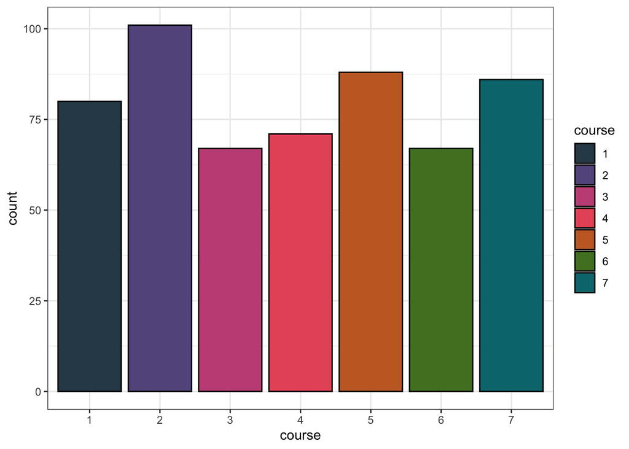

```r
course_palette <- c("1" = "#2F4858", "2" = "#64588C", "3" = "#C65385",
                    "4" = "#E85867", "5" = "#C56A2D", "6" = "#4F8029",
                    "7" = "#00777E",
                    "half-blood" = "#BFA5A5", "muggle-born" = "#006C78", "pure-blood" = "#E85867",
                    "магглорожденный" = "#006C78", "чистокровный" = "#E85867",

                    "Gryffindor" = "#C50000", "Hufflepuff" = "#ECB939", "Ravenclaw" = "#41A6D9",
                    "Slytherin" = "#1F5D25")

ggplot(hogwarts)+
  geom_bar(aes(x = course, fill=course), color='black')+
  scale_fill_manual(values = course_palette)+
  theme_bw()
```

### Task 2

Создайте новый барплот, отражающий распределение числа студентов по факультету. Добавьте на график вторую факторную переменную – происхождение (bloodStatus). Модифицируйте при помощи аргумента position графика так, чтобы каждый столбец показывал распределение факультета по чистоте крови в долях. Примените произвольную тему. Запишите текстом в rmd-документе, какой вывод можно сделать из графика?

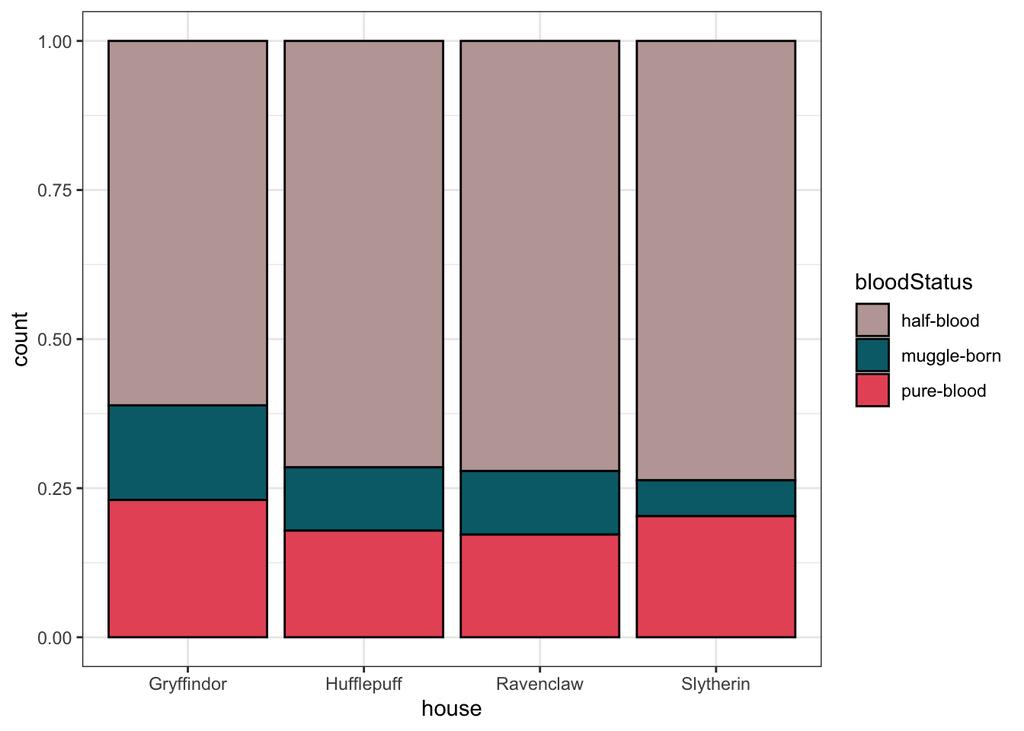

```r
ggplot(hogwarts)+
  geom_bar(aes(x = house, fill=bloodStatus), color='black', position = "fill")+
  scale_fill_manual(values = course_palette)+
  theme_bw()
```

Вывод: среди студентов Хогвартса преобладают полукровки, чуть чаще маглорожденные и чистокровные волшебники встречаются на Гриффиндоре.

### Task 3

Модифицируйте датасет таким образом, чтобы в нем остались только чистокровные (pure-blood) и маглорожденные студенты (muggle-born). Создайте на основе этих данных график из пункта 2. Добавьте горизонтальную пунктирную линию произвольного цвета на уровне 50%. Дайте осям название на русском языке (1б). Дополнительно: переименуйте на русский язык категории легенды pure-blood и muggle-born (0.5 б).

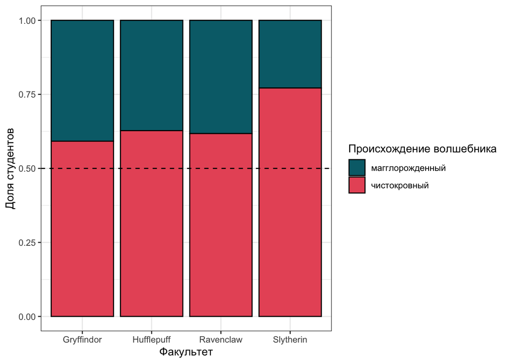

```r
hogwarts_pure_muggle = hogwarts %>%
  filter(bloodStatus %in% c("pure-blood", "muggle-born")) %>%
  mutate(bloodStatusRu = fct_recode(bloodStatus,
                                    "чистокровный" = "pure-blood",
                                     "магглорожденный" = "muggle-born"))

ggplot(hogwarts_pure_muggle)+
  geom_bar(aes(x = house, fill=bloodStatusRu), color='black', position = "fill")+
  scale_fill_manual(values = course_palette)+
  geom_hline(yintercept = 0.5, color = "black", linetype = "dashed")+
  labs(x = "Факультет", y = "Доля студентов", fill = "Происхождение волшебника") +
  theme_bw()
```

## Boxplots

### Task 1

Отобразите распределение баллов, заработанных студентами на 3-й неделе обучения, по факультетам. Отсортируйте факультеты в порядке убывания медианного балла за 3-ю неделю (мы не останавливались на этом в лекции, но упомянутая в ней функция по умолчанию сортирует именно по медиане, так что в этом случае дополнительных аргументов передавать не следует).

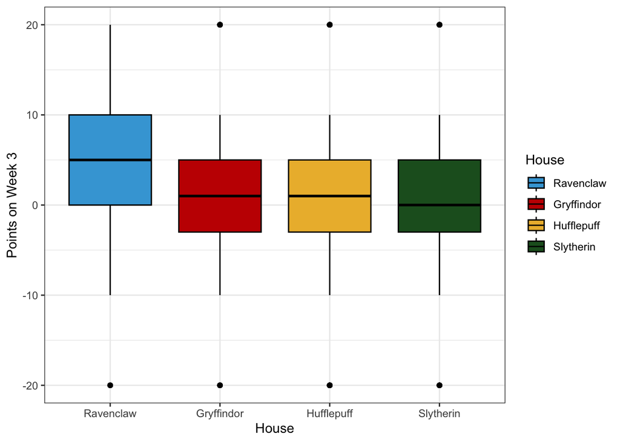

```r
hogwarts %>%
  ggplot()+
  geom_boxplot(aes(y = week_3,
                   x = reorder(house, week_3,
                                  FUN = median,
                                  decreasing = T),
                   fill = reorder(house, week_3,
                                  FUN = median,
                                  decreasing = T)),
               color='black')+
  scale_fill_manual(values = course_palette)+
  labs(x = "House", y = "Points on Week 3", fill = "House") +
  theme_bw()
```

### Task 2

Добавьте отображение разными цветами для происхождения студентов (bloodStatus). Добавьте на боксплот вырезку (notch). Настройте для данного чанка размер изображения 14:14 дюймов. Приведите названия осей к корректному виду.

[output not shown]

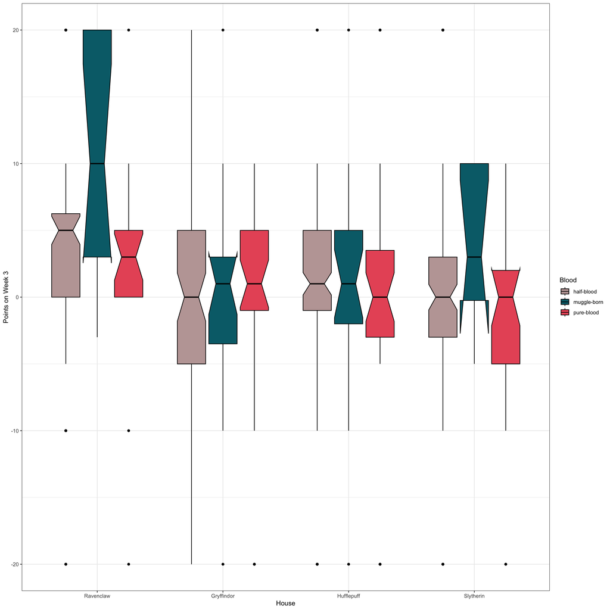

```r
hogwarts %>%
  ggplot()+
  geom_boxplot(aes(y = week_3,
                   x = reorder(house, week_3,
                                  FUN = median,
                                  decreasing = T),
                   fill = bloodStatus),
               color='black', notch = T)+
  scale_fill_manual(values = course_palette)+
  labs(x = "House", y = "Points on Week 3", fill = "Blood") +
  theme_bw()
```

### Task 3

Добавьте на график джиттер-плот. Удалите отображение выбросов у боксплота. Видоизмените по своему вкусу толщину линий и ширину боксплота. Дополнительно: Добавьте название графика и подпись

[output not shown]

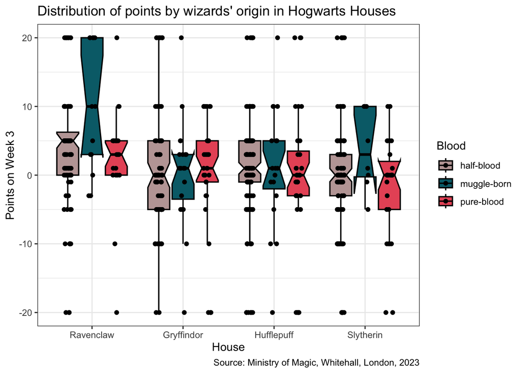

```r
hogwarts %>%
  ggplot()+
  geom_boxplot(aes(y = week_3,
                   x = reorder(house, week_3,
                                  FUN = median,
                                  decreasing = T),
                   fill = bloodStatus),
               color='black',
               size=0.6,
               width=0.8,
               notch = T,
               outlier.shape = NA)+
  geom_jitter(aes(y = week_3,
                   x = reorder(house, week_3,
                                  FUN = median,
                                  decreasing = T),
                  fill = bloodStatus),
              position=position_jitterdodge(jitter.width = 0.2, dodge.width = 0.8))+
  scale_fill_manual(values = course_palette)+
  labs(x = "House", y = "Points on Week 3", fill = "Blood",
       title = "Distribution of points by wizards' origin in Hogwarts Houses",
       caption = "Source: Ministry of Magic, Whitehall, London, 2023") +
  theme_bw()
```

## Miscellaneous

### Task 1

Постройте “леденцовый график” (lollipop-plot) для количества набранных студентами 5-го курса баллов за весь учебный год (по оси ординат – id студента, по оси абсцисс – итоговый балл). Отсортируйте студентов в порядке убывания итогового балла. Раскрасьте точки на “леденцах” в зависимости от сердцевины волшебной палочки. Палочки с сердечной жилой дракона должны быть красного цвета, с пером феникса – желтого, с волосом единорога – серого.

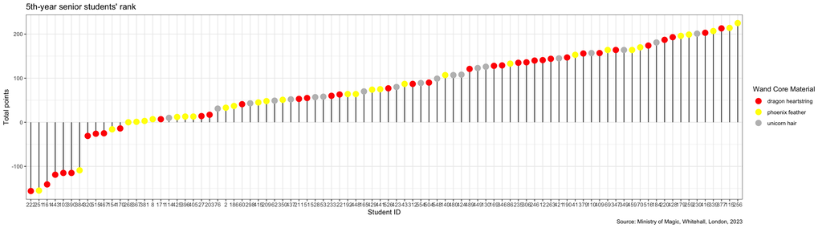

```r
lollipop_palette <- c(
  `dragon heartstring` = 'red',
  `phoenix feather` = 'yellow',
  `unicorn hair` = "grey"
)

hogwarts %>%
  filter(course == '5') %>%
  arrange(desc(result)) %>%
  ggplot()+
  geom_segment(aes(x = reorder(id, result),
                   xend = reorder(id, result),
                   y = 0,
                   yend = result),
               color = "black") +
  geom_point(aes(x = reorder(id, result), y = result, color = reorder(wandCore, result)), size = 4) +
  scale_color_manual(values = lollipop_palette)+
  labs(x = "Student ID", y = "Total points", color = "Wand Core Material",
       title = "5th-year senior students' rank",
       caption = "Source: Ministry of Magic, Whitehall, London, 2023") +
  theme_bw()
```

### Task 2

Постройте гистограмму распредления баллов за экзамен по астрономии. Выделите цветом факультет Слизерин. Примените 18-й кегль к тексту на осях x, y и легенды. Название оси y и легенды запишите 20-м кеглем, оси x – 22-м. Измените название оси y на “Number of students”.

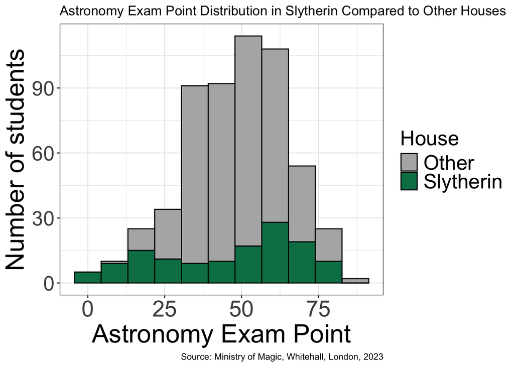

```r
theme_custom <- theme(
    axis.text = element_text(size = 20),
    axis.title = element_text(size = 25),
    axis.text.y = element_text(size = 20),
    axis.text.x = element_text(size = 22),
    legend.title = element_text(size = 20),
    legend.text = element_text(size = 20))

hogwarts %>%
  mutate(Slytherin_Bin = ifelse(house == "Slytherin", "Slytherin", "Other")) %>%
  ggplot() +
  geom_histogram(aes(x = `Astronomy exam`, fill = Slytherin_Bin),
               colour = "black",
               bins = ceiling(log2(nrow(hogwarts))+1)) +
  scale_fill_manual(values = c("Slytherin" = "#007E55", "Other" = "grey70")) +
  labs(x = "Astronomy Exam Point", y = "Number of students",
       fill = "House",
       title = "Astronomy Exam Point Distribution in Slytherin Compared to Other Houses",
       caption = "Source: Ministry of Magic, Whitehall, London, 2023") +
  theme_bw()+
  theme_custom
```

### Task 3

На лекции мы использовали комбинацию theme_bw(), и созданной нами theme_custom, чтобы одновременно сделать фон белым и увеличить шрифт. Модифицируйте theme_custom таким образом, чтобы она и выполняла свои прежние функции, и делала фон белым без помощи theme_bw(). Примените новую кастомную тему к графику, полученному в последнем пункте блока по боксплотам

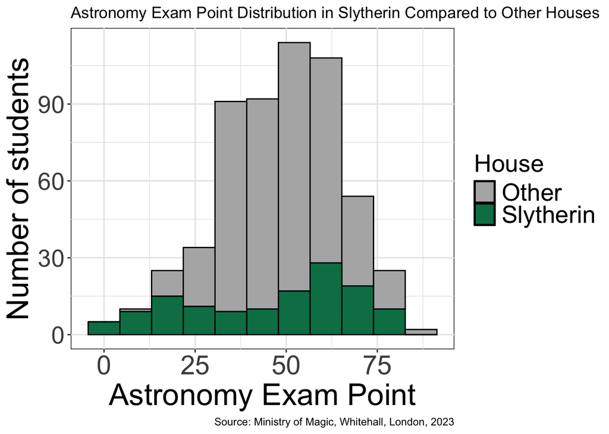

```r
theme_custom <- theme(
    panel.background = element_rect(fill = "white", color = "black"),
    plot.background = element_rect(fill = "white", color = "white"),
    panel.grid = element_line(color = "grey90"),
    axis.text = element_text(size = 20),
    axis.title = element_text(size = 25),
    axis.text.y = element_text(size = 20),
    axis.text.x = element_text(size = 22),
    legend.title = element_text(size = 20),
    legend.text = element_text(size = 20))

hogwarts %>%
  mutate(Slytherin_Bin = ifelse(house == "Slytherin", "Slytherin", "Other")) %>%
  ggplot() +
  geom_histogram(aes(x = `Astronomy exam`, fill = Slytherin_Bin),
               colour = "black",
               bins = ceiling(log2(nrow(hogwarts))+1)) +
  scale_fill_manual(values = c("Slytherin" = "#007E55", "Other" = "grey70")) +
  labs(x = "Astronomy Exam Point", y = "Number of students",
       fill = "House",
       title = "Astronomy Exam Point Distribution in Slytherin Compared to Other Houses",
       caption = "Source: Ministry of Magic, Whitehall, London, 2023") +
  theme_custom
```

## Facets

### Task 1

Напишите, какой, по вашему мнению, способ фасетирования (по строкам или по столбцам) лучше использовать для визуализации гистограммы. Почему? А какой для визуализации violin-plot? Почему? Можно ли вывести общее правило? (1.5 б)

*Ответ: Я бы использовал для визуализации гистограмм только фасетирование по столбцам, так как они лучше помещаются в поле зрения. Для violin-plot в общем случае я бы тоже использовал фасетирование по столбцам, но если число групп в violin-plot достаточно большое, тогда я бы использовал фасетирование по строкам, чтобы не перегружать график.*

### Task 2

Постройте гистограмму для результата любого выбранного вами экзамена, кроме зельеварения. Настройте оптимальное на ваш взгляд число столбцов гистограммы. Выполните фасетирование по курсу. Постарайтесь, чтобы график был по возможности компактным.

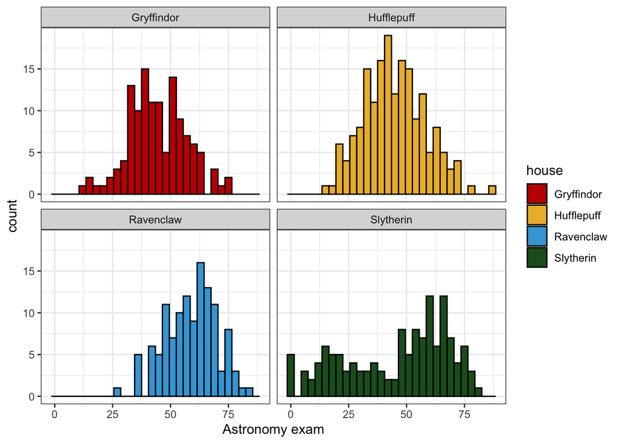

```r
hogwarts %>%
  ggplot() +
  geom_histogram(aes(x = `Astronomy exam`, fill=house), color="black")+
  facet_wrap(vars(house)) +
  scale_fill_manual(values = course_palette) +
  theme_bw()
```

### Task 3

Отобразите на одном графике распределение плотности вероятности для оценки студентов на экзамене по защите от темных искусств и на экзамене по травологии. Раскрасьте их в любые выбранные вами цвета, постарайтесь, чтобы оба распределения отображались целиком. Примените тему из 3-го пункта блока “Разное”. Сделайте фасетирование по полу.

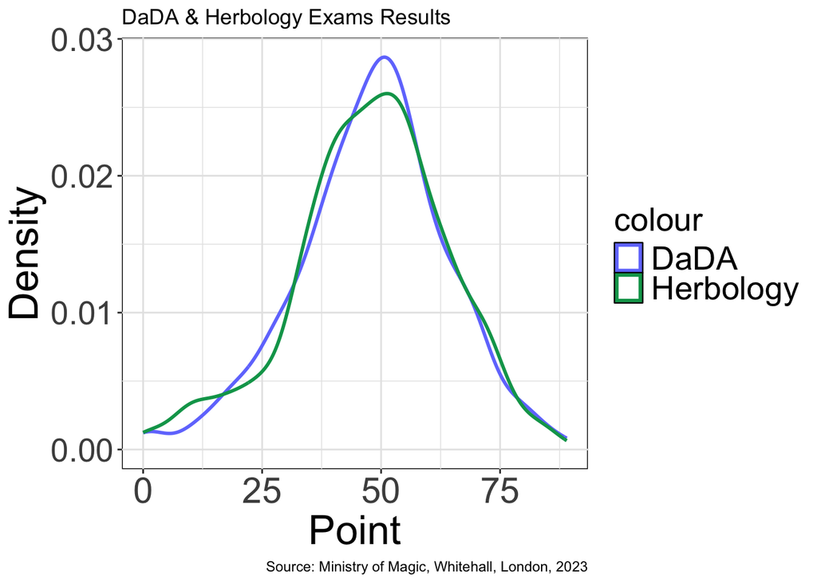

```r
theme_custom <- theme(
    panel.background = element_rect(fill = "white", color = "black"),
    plot.background = element_rect(fill = "white", color = "white"),
    panel.grid = element_line(color = "grey90"),
    axis.text = element_text(size = 20),
    axis.title = element_text(size = 25),
    axis.text.y = element_text(size = 20),
    axis.text.x = element_text(size = 22),
    legend.title = element_text(size = 20),
    legend.text = element_text(size = 20))

hogwarts %>%
  ggplot() +
  geom_density(aes(x = `Defence against the dark arts exam`, color = "DaDA"), size = 1) +
  geom_density(aes(x = `Herbology exam`, color = "Herbology"), size = 1) +
  scale_color_manual(values = c("DaDA" = "#717CFD", "Herbology" = "#00A259")) +
  labs(x = "Point", y = "Density",
       fill = "Exam",
       title = "DaDA & Herbology Exams Results",
       caption = "Source: Ministry of Magic, Whitehall, London, 2023") +
  theme_custom
```